# note12

### 메트로폴리스-헤이스팅스

### 예제1

다시 $B(2.7,6.3)$를 추출하는 예제로 돌아오자.

#### 시도1

`-` 우선 우리가 관심이 있는 타겟분포를 그려보자.

```r
f<-function(x){
    alpha=2.7
    beta=6.3
    gamma(alpha+beta)/gamma(alpha)/gamma(beta) * x^(alpha-1)*(1-x)^(beta-1)
}
```

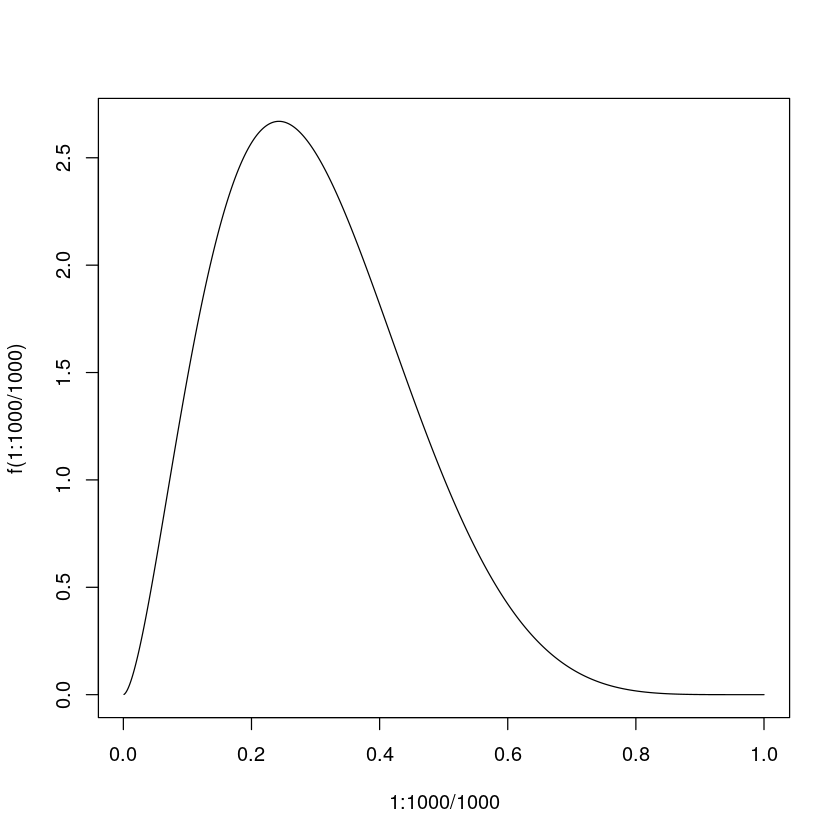

```r
plot(1:1000/1000,f(1:1000/1000),type='l')
```

```r
X<-rep(0.1,5000)
```

```r
print(head(X))
```

```
[1] 0.1 0.1 0.1 0.1 0.1 0.1
```

`-` 현재 $X$의 값은 모두 0.1이다. 그런데 궁극적으로는 $X$의 값을 모두 $Beta(2.7,6.3)$에서 생성된 샘플들로 채우고 싶다.

```r
set.seed(1)
Y<-runif(1)
print(Y)
```

```
[1] 0.2655087
```

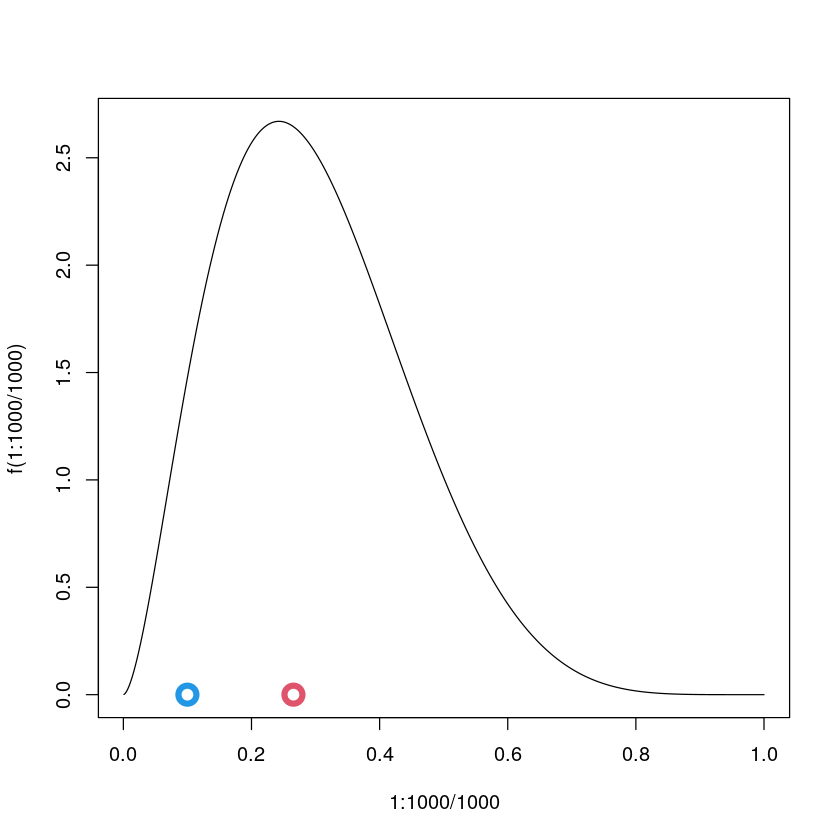

```r
plot(1:1000/1000,f(1:1000/1000),type='l')
points(Y,0,col=2,cex=2,lwd=5)
points(X[1],0,col=4,cex=2,lwd=5)
```

`–` 빨간점이 $Y$이고 파란점은 $X$이다. 두개의 점중에서 어떤것이 $f(x)$에서 생성되었다고 믿어지는 점일까?

`-` 빨간색 점이 더 가능성이 높아보인다. (pdf값이 더 높음)

`-` $X[2]$의 값은 그냥 빨강으로 결정하자.

```r
X[2]<-Y
```

```r
print(head(X))
```

```
[1] 0.1000000 0.2655087 0.1000000 0.1000000 0.1000000 0.1000000
```

`-` 다시 $Y$를 하나 뽑자.

```r
set.seed(2)
Y<-runif(1)
print(Y)
```

```
[1] 0.1848823
```

`-` 다시 뽑은 $Y$는 초록색으로 표현하자.

```r
plot(1:1000/1000,f(1:1000/1000),type='l')
points(Y,0,col=3,cex=2,lwd=5)
points(X[2],0,col=2,cex=2,lwd=5)
```

[output not shown]

`–` 둘중에 어떤것이 더 $Beta(2.7,6.3)$에서 추출한 샘플 같은가?

`-` 여전히 빨강이 더 $Beta(2.7,6.3)$의 분포에서 나온것 같다.

`-` 그러면 $X[3]$의 값도 그냥 빨강으로 한다.

`-` 지금까지의 결과를 요약하면 아래와 같다.

| $t$ | $X_t$ | $Y_t$ | 설명 |
| --- | --- | --- | --- |
| $1$ | $0.1$ | $0.2655087$ | $Y_1$이 $X_1$보다 더 $Beta(2.7,6.3)$에서 나온 분포같았음 $\to$ $X_2$는 $Y_1$로 선택 |
| $2$ | $0.2655087$ | $0.1848823$ | 이번에는 $X_2$가 $Y_2$보다 더 $Beta(2.7,6.3)$에서 나온 분포같음 $\to$ $X_3$는 $X_2$로 선택 |
| $3$ | $0.2655087$ | $-$ | - |
| $\dots$ | $\dots$ | $\dots$ | $\dots$ |

`–` 이걸 무한대로 반복하면 $X_t$는 결국 $Beta(2.7,6.3)$에서 뽑혔을법한 샘플들로 점점 채워진다.

`-` 따라서 $\{X_1,X_2,X_3,\dots,X_{5000}\}$을 모아서 히스토그램을 그리면 적당히 $Beta(2.7,6.3)$에서 추출한 표본이라 주장할 수 있을것 같다.

`-` 앞부분은 내가 임의로 값을 주는것에 따라 다르니까 대충 앞에 100개정도는 버리고 $\{X_{101},X_{102},\dots,X_{5000}\}$를 모아서 히스토그램을 그리면 좀 더 좋은 그림이 나올것 같다.

#### 시도2

`-` 시도1의 당연한 우려점은 특정시점 이후에는 $X_t$는 거의 하나의 값만 나올것 같다는 것이다.

`-` 즉 우연히 $X_t$가 pdf의 최고점에서 찍힌다면, 그 이후에는 거의 $X_t$는 하나의 값만 나올것

`-` 당장 위의 예제만 살펴봐도 $X_4, X_5,X_6,\dots$ 뽑아보았자 당분간은 $X_4=X_5=X_6=..=0.2655087$ 일것 같다.

`-` 히스토그램을 그려봤자 다 $0.2655087$에만 값이 몰려있을 것이다.

`-` 더 그럴듯한 샘플을 선택하는 아이디어는 좋은데, 그런식으로 진행하면 결국 반복할수록 pdf의 최고점을 향해 달려가는 꼴밖에 안된다.

`-` 다시 아래의 그림을 관찰해보자.

```r
plot(1:1000/1000,f(1:1000/1000),type='l')
points(Y,0,col=3,cex=2,lwd=5)
points(X[2],0,col=2,cex=2,lwd=5)
```

[output not shown]

`-` 초록색점보다 빨간색 점이 더 pdf값이 높으므로 빨간색점이 더 $Beta(2.7,6.3)$에서 나왔음직한 샘플인것은 맞다.

`-` 그런데 $100\%$ 확신할 수 있는가?

`-` 빨간색점 0.2655087 에서의 pdf값은 아래와 같다.

```r
f(0.2655087)
```

2.64480579727479

`–` 반면 초록색점 0.1848823 에서의 pdf값은 아래와 같다.

```r
f(0.1848823)
```

2.48267809218198

`–` 사실 초록색점도 가능성 있는 점이다. 만약에 어떤사람이 $Beta(2.7,6.3)$에서 하나의 확률변수를 생성하고 나머지는 $U[0,1]$에서 생성했다고 치자. 두 결과를 초록색과 빨간색으로 표시되었다고 할때 어떤색이 $Beta(2.7,6.3)$에서 생성되었냐고 묻는다면 당신은 빨간색을 고를 것이다.

`-` 하지만 빨간색에 전재산을 베팅할 수 있는가?

```r
f(0.2655087) / (f(0.2655087)+f(0.1848823))
```

0.515809674743804

`-` 빨간색에 $51.58\%$의 재산만 베팅한다.

`-` 즉 빨간색이 $Beta(2.7,6.3)$에서 왔다고 믿을 확률이 $51.58\%$정도라는 의미이다.

`-` 제안하는 알고리즘

(1) $X_1$에 아무값이나 넣는다.

(2) 균등분포에서 $Y_1$을 뽑는다.

(3) $\frac{f(Y_1)}{f(X_1)+f(Y_1)}$의 확률로 $X_2=Y_1$을 선택하고 $\frac{f(X_1)}{f(X_1)+f(Y_1)}$의 확률로 $X_2=X_1$을 선택한다.

(4) (2)-(3)를 반복한다.

`-` 실행

```r
X<-rep(0.1,5000)
for (i in 2:5000){
    Y<-runif(1)
    acceptance_prob<-f(Y)/(f(X[i])+f(Y))
    U_<-runif(1)
    X[i]<- Y* (U_< acceptance_prob) +X[i-1] * (U_> acceptance_prob)
}
```

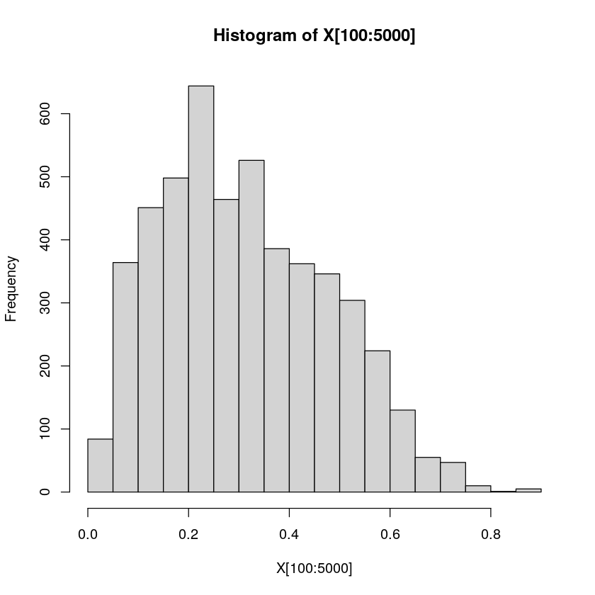

```r
hist(X[100:5000])
```

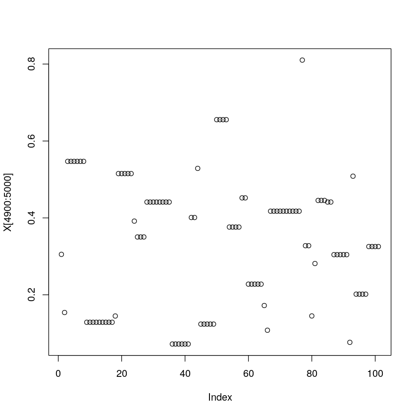

```r
plot(X[4900:5000])
```

`–` 분명히 $X_t$와 $X_{t-1}$는 종속되어있다. 그런데 전체 분포를 그려보니까 $Beta(2.7,6.3)$의 히스토그램 같다.

`-` 이 알고리즘이 왜 성립하는가?

`-` 그러고 보니까 이 느낌을 어디서 받았다. (에르고딕, 정상성)

#### 시도2의 이론적 근거

`-` 주장하고 싶은 것은 아래와 같다.

- 타겟분포: $X_t$의 극한분포는 $Beta(2.7,6.3)$이다.
- 에르고드성: $X_{\infty}$의 분포인 $Beta(2.7,6.3)$의 hist는 $X_{100} \sim X_{\infty}$의 샘플(타임샘플?)을 바탕으로 히스토그램을 그려도된다.

`-` $X_t$는 정상분포를 가지고 그 확률밀도함수가 $f(x)$임을 보이면 된다.

`-` 분포 $f$가 아래의 조건(detailed balance condition)을 만족시키는지를 체크하면 된다.

$$f(x_{t+1})P(x_t|x_{t+1})=f(x_t)P(x_{t+1}|x_t) \quad \cdots (\star\star)$$

`–` $x_{t+1}=x_t$ 이라면 그냥 성립한다.

`-` $x_{t+1}\neq x_t$ 일때 성립하는지 봐야한다. ($x_{t+1}=y_t$)

`–` $P(x_{t+1}|x_{t})=\frac{f(x_{t+1})}{f(x_t)+f(x_{t+1})}$

`–` $x_t$와 $x_{t+1}$의 순서를 바꾸면 $P(x_t|x_{t+1})=\frac{f(x_t)}{f(x_{t})+f(x_{t+1})}$

`–` $P(x_{t+1}|x_t)$와 $P(x_t|x_{t+1})$를 detailed balance condition $(\star\star)$에 대입하면 등호가 성립함을 쉽게 체크할 수 있다.

#### 시도3

`-` 매트로폴리스의 제안을 살펴보자.

`-` 매트로폴리스: 나는 $P(x_{t+1}|x_t)= \min\left (1,\frac{f(x_{t+1})}{f(x_t)} \right)$를 쓰겠다!

`–` 왜??

`-` 매트로폴리스의 제안을 곰곰히 살펴보니까 $f(x_{t+1})>f(x_t)$ 이라면 100% 확률로 $x_t \to x_{t+1}$로의 전환이 일어난다. 새로운 제안이 조금이라도 낫다고 생각되면 무조건 이동하고, 새로운 제안이 약간 안 좋아도 높은확률로 이동한다.

`-` 다시 아래의 그림을 고려하자.

```r
plot(1:1000/1000,f(1:1000/1000),type='l')
points(0.1848823,0,col=3,cex=2,lwd=5)
points(0.2655087,0,col=2,cex=2,lwd=5)
```

[output not shown]

`-` 초록색이 새로운 제안이다.

`-` 빨간색에 비하여 부족해 보인다.

```r
print(f(0.2655087)) ## 빨간색
print(f(0.1848823)) ## 초록색
```

```
[1] 2.644806
[1] 2.482678
```

`–` 그래도 이동한다.

```r
f(0.1848823)/f(0.2655087)
```

0.938699580415369

`-` 무려 93%의 확률로 이동한다.

`-` 매트로폴리스의 알고리즘은 많은 경우 $x_t\neq x_{t+1}$이다. 즉 $x_t$와 $x_{t+1}$이 조금 덜 연관되어 보인다.

`-` 그런데 매트로폴리스의 제안이 과연 detailed balance condition을 만족할까?

$$P(x_{t+1}|x_t)f(x_t)=P(x_t|x_{t+1})f(x_{t+1})$$

- $P(x_{t+1}|x_t)= \min\left (1,\frac{f(x_{t+1})}{f(x_t)} \right):=A$
- $P(x_{t}|x_{t+1})= \min\left (1,\frac{f(x_{t})}{f(x_{t+1})} \right):=B$

`–` 그럼 detailed balance condition은 아래와 같다.

$$Af(x_t)=Bf(x_{t+1})$$

`–` 경우1: $f(x_{t+1})>f(x_t)$ 라고 가정하자.

그러면 $A=1$, $B=\frac{f(x_t)}{f(x_{t+1})}$ 이 된다.

따라서 detailed balance condition이 성립한다.

`-` 경우2: $f(x_{t+1})< f(x_t)$ 라고 가정하자.

그러면 $A=\frac{f(x_{t+1})}{f(x_t)}, B=1$이 된다.

따라서 detailed balance condition이 성립한다.

`-` 경우3: $f(x_{t+1})=f(x_t)$ 이면 그냥 성립.

(초보단계의) 매트로폴리스-헤이스팅스 알고리즘

`-` 메트로폴리스의 알고리즘을 요약하면 아래와 같다.

(1) $X_1$에 아무값이나 넣는다.

(2) $t=2,3,4,\dots$에 대하여 아래를 반복한다.

- $Y_t$를 균등분포에서 뽑고
- $\min\left(1, \frac{f(y_t)}{f(x_t)}\right)$의 확률로 $X_{t+1}=Y_t$를 선택하고 그 외의 확률로 $X_{t+1}=X_t$를 선택한다.

```r
X<-rep(0.1,5000)
for (i in 2:5000){
    Y<-runif(1)
    acceptance_prob<- min(1,f(Y)/f(X[i]))
    U_ <- runif(1)
    X[i]<- Y* (U_<acceptance_prob) + X[i-1]*(U_> acceptance_prob)
}
```

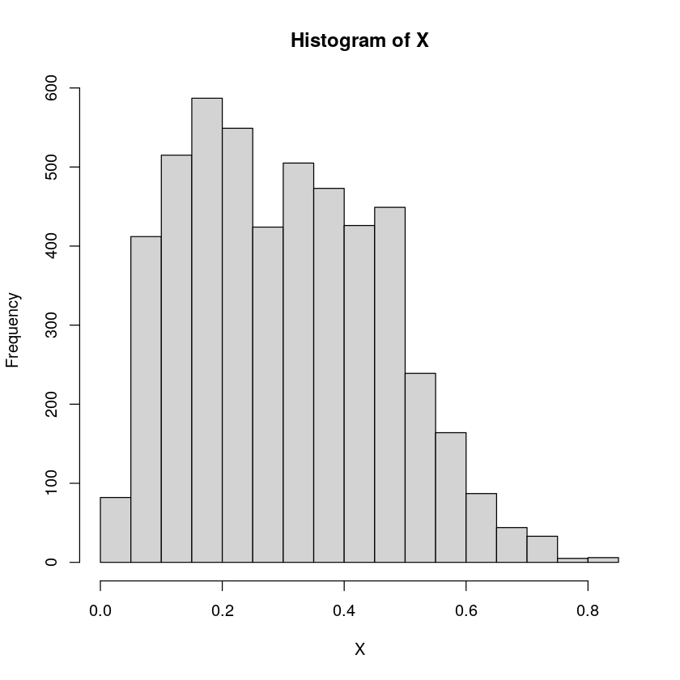

```r
hist(X)
```

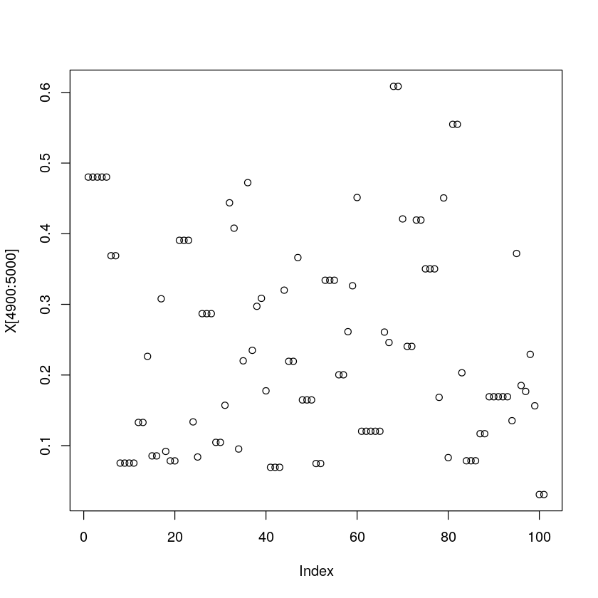

```r
plot(X[4900:5000])
```

### 시도4

`-` $Y$를 균등분포가 아닌 다른분포에서 뽑아도 가능할 것 같다.

`-` 예를들면 $Y \sim Beta(2,6)$에서 추출한다고 해보자.

```r
g<-function(x){
    alpha=2
    beta=6
    gamma(alpha+beta)/gamma(alpha)/gamma(beta) * x^(alpha-1)*(1-x)^(beta-1)
}
```

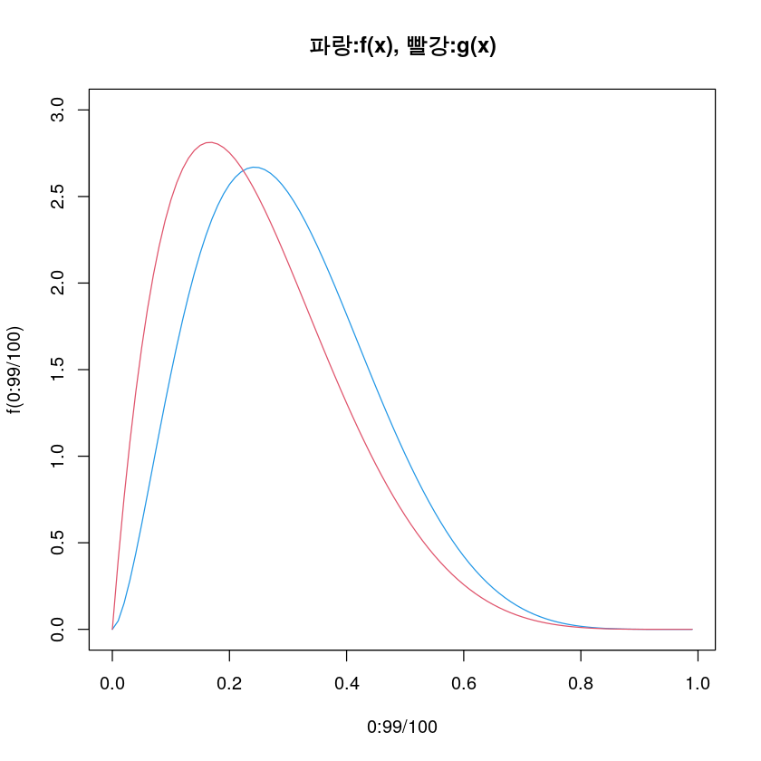

```r
plot(0:99/100,f(0:99/100),type='l',col=4,ylim=c(0,3),main="파랑:f(x), 빨강:g(x)")
lines(0:99/100,g(0:99/100),col=2)
```

```r
set.seed(1)
Y=rbeta(1,shape1=2,shape2=6)
Y
```

0.151649741588921

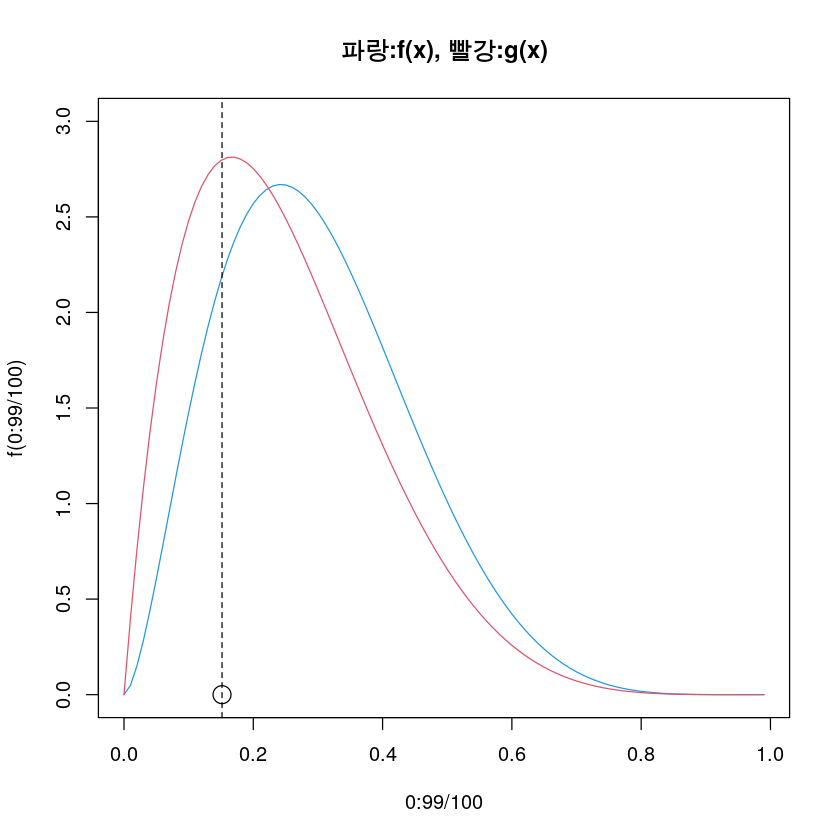

```r
plot(0:99/100,f(0:99/100),type='l',col=4,ylim=c(0,3),main="파랑:f(x), 빨강:g(x)")
lines(0:99/100,g(0:99/100),col=2)
points(Y,0,cex=2); abline(v=Y,lty=2)
```

참조분포가 균등분포였으면 $Y$를 타겟분포의 샘플이라고 믿을 수도 있었음.

그런데 참조분포가 붉은선의 pdf를 가지므로 $Y$가 타겟분포의 샘플이라 믿기 어려워 졌음.

수락확률이 수정되어야 한다.

- 기존의 수락확률: $\min\left(1,\frac{f(Y_t)}{f(x_t)}\right)$
- 수정된 수락확률: $\min\left(1,\frac{f(Y_t)g(x_t)}{f(x_t)g(Y_t)}\right)$

```r
X<-rep(0.1,5000)
for (i in 2:5000){
    Y<-rbeta(1,shape1=2,shape2=6)
    acceptance_prob<-min(1,f(Y)*g(X[i])/f(X[i])/g(Y))
    U_<- runif(1)
    X[i]<- Y* (U_<acceptance_prob) + X[i-1]*(U_> acceptance_prob)
}
```

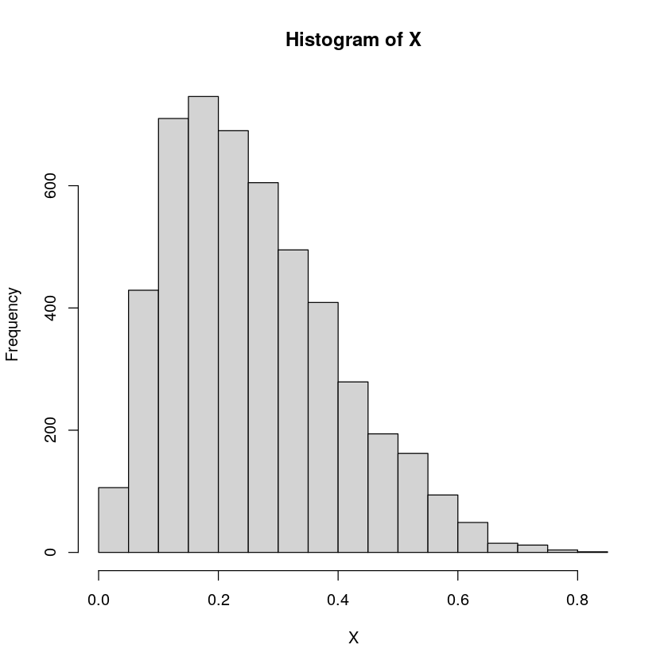

```r
hist(X)
```

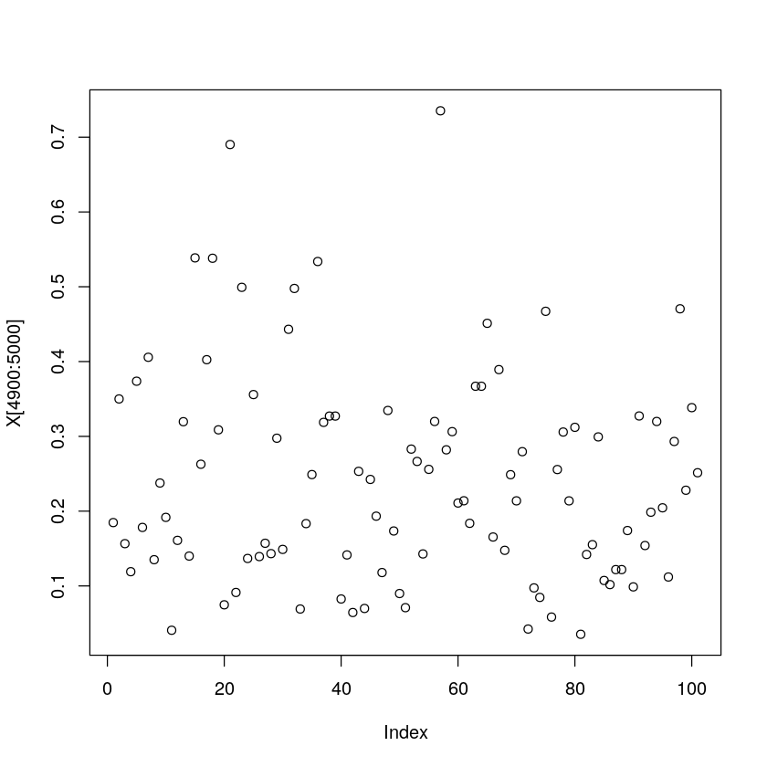

```r
plot(X[4900:5000])
```

*[수정된 알고리즘]*

(1) $X_1$에 아무값이나 넣는다.

(2) $t=2,3,4,\dots$에 대하여 아래를 반복한다.

- $Y_t$를 $g$에서 뽑고
- $\min\left(1, \frac{f(Y_t)g(x_t)}{f(x_t)g(Y_t)}\right)$의 확률로 $X_{t+1}=Y_t$를 선택하고 그 외의 확률로 $X_{t+1}=X_t$를 선택한다.